# Estadística avanzada: Análisis estadístico I

# A2 - Analítica descriptiva e inferencial

Autor: Eduardo Mora González

Noviembre 2022

```r
 library(readr)
 gpa <- read_csv("C:/Users/eduar/Dropbox/ESTUDIOS/Estadística avanzada/PEC2/gpa_clean.csv")
# Numero de campos, registros y tipos las variables
str(gpa)
```

```
## spec_tbl_df [4,137 x 11] (S3: spec_tbl_df/tbl_df/tbl/data.frame)
##  $ sat      : num [1:4137] 920 1170 810 940 1180 980 880 980 1240 1230 ...
##  $ tothrs   : num [1:4137] 43 18 14 40 18 114 78 55 18 17 ...
##  $ hsize    : num [1:4137] 0.1 9.4 1.19 5.71 2.14 ...
##  $ hsrank   : num [1:4137] 4 191 42 252 86 41 161 101 161 3 ...
##  $ hsperc   : num [1:4137] 40 20.3 35.3 44.1 40.2 ...
##  $ colgpa   : num [1:4137] 2.04 4 1.78 2.42 2.61 ...
##  $ athlete  : logi [1:4137] TRUE FALSE TRUE FALSE FALSE FALSE ...
##  $ female   : logi [1:4137] TRUE FALSE FALSE FALSE FALSE TRUE ...
##  $ white    : logi [1:4137] FALSE TRUE TRUE TRUE TRUE TRUE ...
##  $ black    : logi [1:4137] FALSE FALSE FALSE FALSE FALSE FALSE ...
##  $ gpaletter: chr [1:4137] "C" "A" "C" "C" ...
##  - attr(*, "spec")=
##   .. cols(
##   ..   sat = col_double(),
##   ..   tothrs = col_double(),
##   ..   hsize = col_double(),
##   ..   hsrank = col_double(),
##   ..   hsperc = col_double(),
##   ..   colgpa = col_double(),
##   ..   athlete = col_logical(),
##   ..   female = col_logical(),
##   ..   white = col_logical(),
##   ..   black = col_logical(),
##   ..   gpaletter = col_character()
##   .. )
##  - attr(*, "problems")=<externalptr>
```

# 1 Estadística descriptiva y visualización

## 1.1 Análisis descriptivo

```r
# Análisis descriptivo básico de las variables
summary(gpa)
```

```
##       sat           tothrs           hsize          hsrank
##  Min.   : 470   Min.   :  6.00   Min.   :0.03   Min.   :  1.00
##  1st Qu.: 940   1st Qu.: 17.00   1st Qu.:1.65   1st Qu.: 11.00
##  Median :1030   Median : 47.00   Median :2.51   Median : 30.00
##  Mean   :1030   Mean   : 52.83   Mean   :2.80   Mean   : 52.83
##  3rd Qu.:1120   3rd Qu.: 80.00   3rd Qu.:3.68   3rd Qu.: 70.00
##  Max.   :1540   Max.   :137.00   Max.   :9.40   Max.   :634.00
##      hsperc            colgpa       athlete          female
##  Min.   : 0.1667   Min.   :0.000   Mode :logical   Mode :logical
##  1st Qu.: 6.4328   1st Qu.:2.210   FALSE:3943      FALSE:2277
##  Median :14.5833   Median :2.660   TRUE :194       TRUE :1860
##  Mean   :19.2371   Mean   :2.654
##  3rd Qu.:27.7108   3rd Qu.:3.120
##  Max.   :92.0000   Max.   :4.000
##    white           black          gpaletter
##  Mode :logical   Mode :logical   Length:4137
##  FALSE:308       FALSE:3908      Class :character
##  TRUE :3829      TRUE :229       Mode  :character
##
##
##
```

```r
# Dimensiones
dim(gpa)
```

```
## [1] 4137   11
```

## 1.2 Visualización

### 1.2.1 Distribución de las variables ’sat‘ y ’colgpa‘

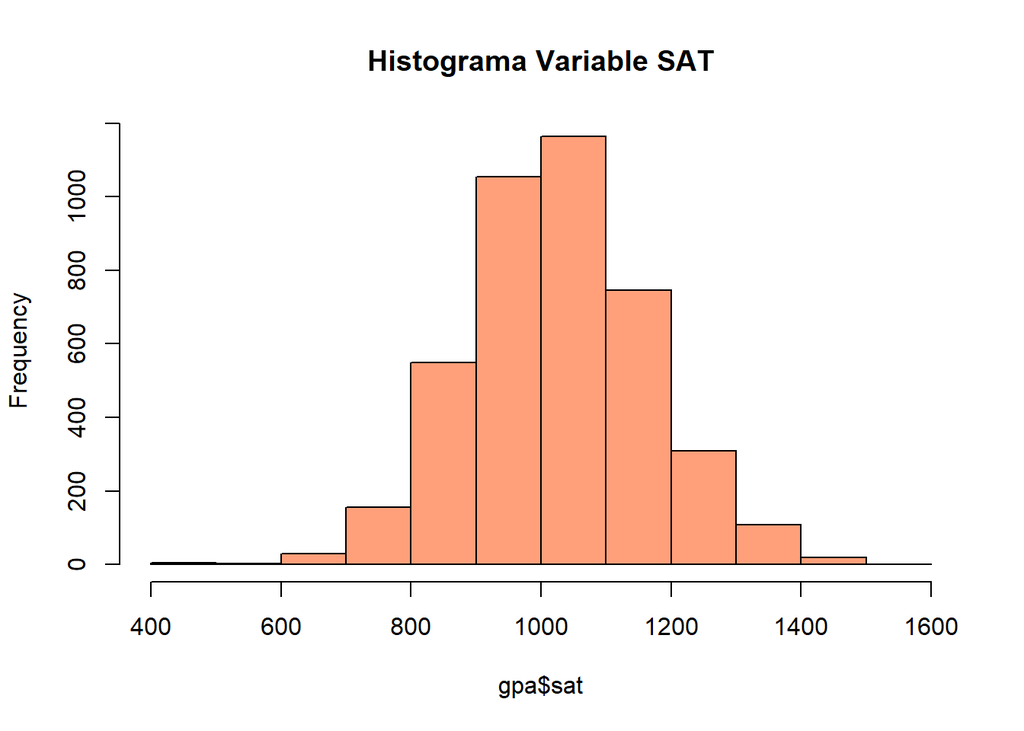

```r
hist(gpa$sat,col="lightsalmon",main="Histograma Variable SAT")
```

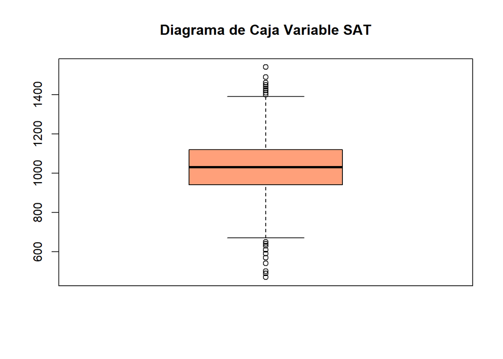

```r
boxplot(gpa$sat,col="lightsalmon",main="Diagrama de Caja Variable SAT")
```

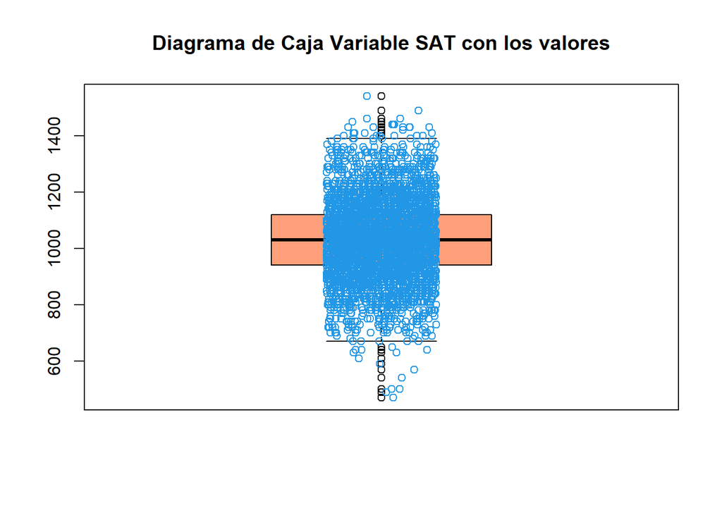

```r
boxplot(gpa$sat,col="lightsalmon",main="Diagrama de Caja Variable SAT con los valores")

# Points
stripchart(gpa$sat,
           method = "jitter",
           pch = 1,
           col = 4,
           vertical = TRUE,
           add = TRUE)
```

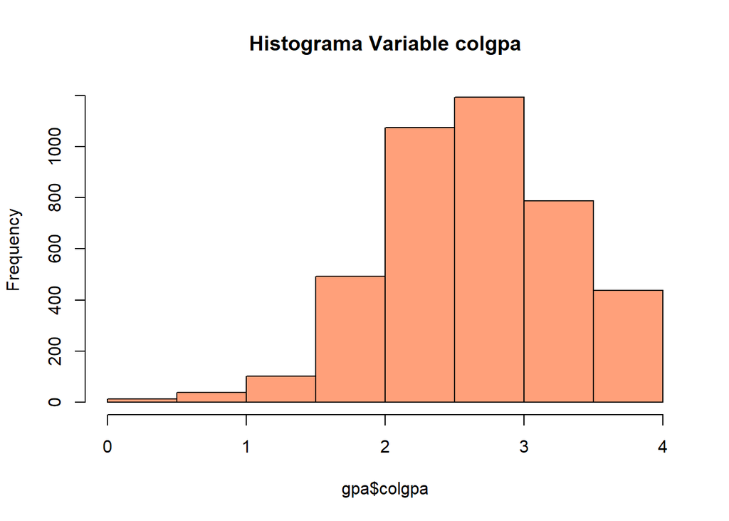

```r
hist(gpa$colgpa,col="lightsalmon",main="Histograma Variable colgpa")
```

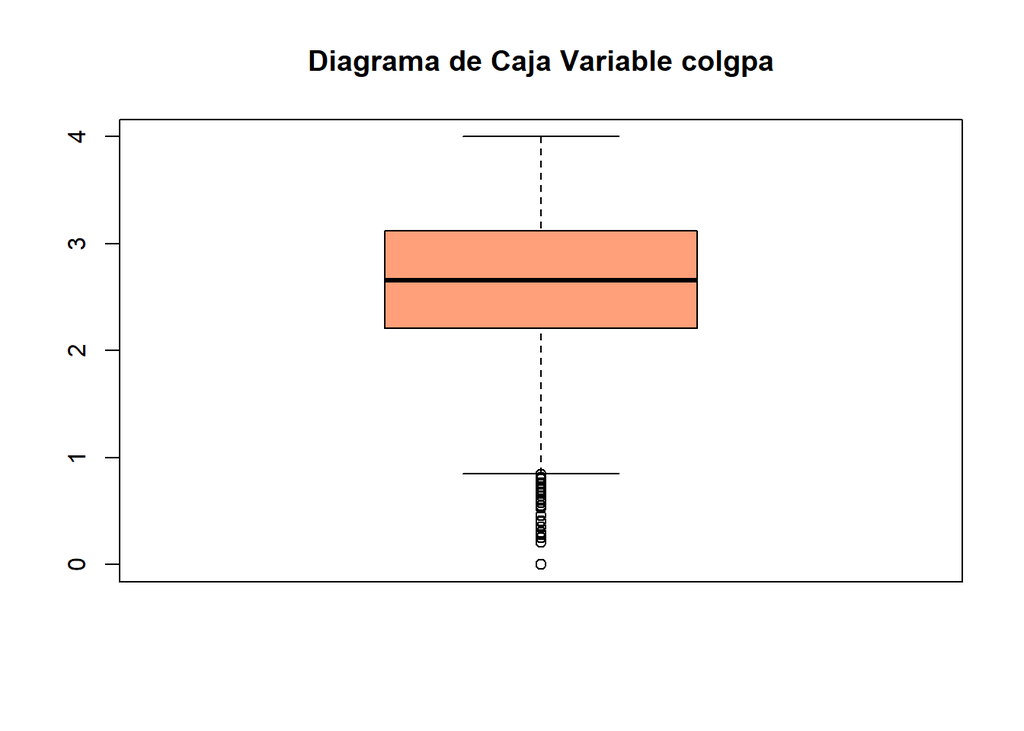

```r
boxplot(gpa$colgpa,col="lightsalmon",main="Diagrama de Caja Variable colgpa")
```

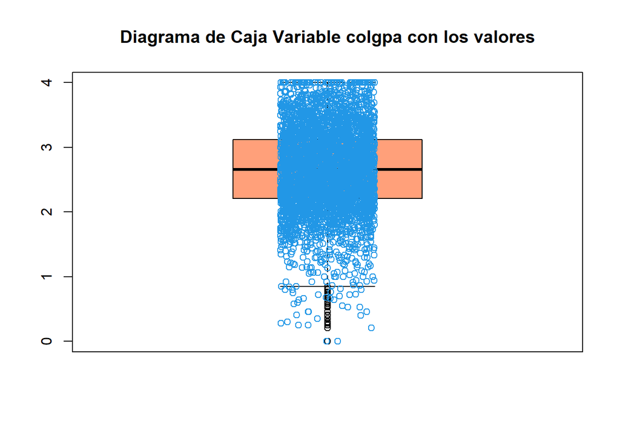

```r
boxplot(gpa$colgpa,col="lightsalmon",main="Diagrama de Caja Variable colgpa con los valores")

# Points
stripchart(gpa$colgpa,
           method = "jitter",
           pch = 1,
           col = 4,
           vertical = TRUE,
           add = TRUE)
```

### 1.2.2 Distribución de la variable ’sat‘ con respecto a la variable género (’female‘), la variable atleta (’athlete‘) y la raza (’white‘, ’black‘)

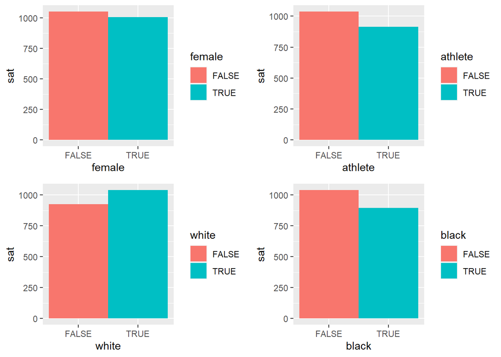

```r
Sum1 <- summarize( group_by(gpa, female), n=length(female), sat=mean(sat))
Sum2 <- summarize( group_by(gpa, athlete), n=length(athlete), sat=mean(sat))
Sum3 <- summarize( group_by(gpa, white), n=length(white), sat=mean(sat))
Sum4 <- summarize( group_by(gpa, black), n=length(black), sat=mean(sat))
g1 <-  ggplot( Sum1, aes(x=female, y=sat, fill=female)) + geom_bar(width = 1, stat = "identity")
g2 <-  ggplot( Sum2, aes(x=athlete, y=sat, fill=athlete)) + geom_bar(width = 1, stat = "identity")
g3 <-  ggplot( Sum3, aes(x=white, y=sat, fill=white)) + geom_bar(width = 1, stat = "identity")
g4 <-  ggplot( Sum4, aes(x=black, y=sat, fill=black)) + geom_bar(width = 1, stat = "identity")

grid.arrange(g1,g2, g3, g4, nrow=2)
```

### 1.2.3 Realizad el mismo tipo de visualizaciones con la variable ’colgpa‘ y las variables ’female‘, ’athlete‘ y ’white‘/’black‘.

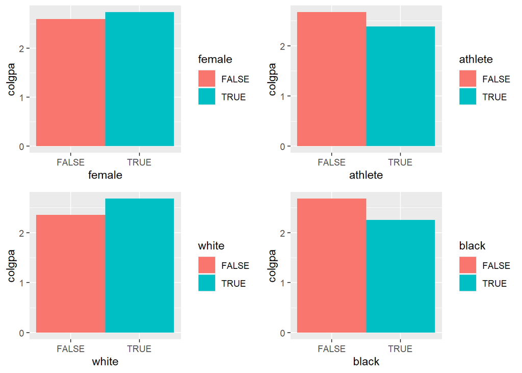

```r
Sum1 <- summarize( group_by(gpa, female), n=length(female), colgpa=mean(colgpa))
Sum2 <- summarize( group_by(gpa, athlete), n=length(athlete), colgpa=mean(colgpa))
Sum3 <- summarize( group_by(gpa, white), n=length(white), colgpa=mean(colgpa))
Sum4 <- summarize( group_by(gpa, black), n=length(black), colgpa=mean(colgpa))
g1 <-  ggplot( Sum1, aes(x=female, y=colgpa, fill=female)) + geom_bar(width = 1, stat = "identity")
g2 <-  ggplot( Sum2, aes(x=athlete, y=colgpa, fill=athlete)) + geom_bar(width = 1, stat = "identity")
g3 <-  ggplot( Sum3, aes(x=white, y=colgpa, fill=white)) + geom_bar(width = 1, stat = "identity")
g4 <-  ggplot( Sum4, aes(x=black, y=colgpa, fill=black)) + geom_bar(width = 1, stat = "identity")

grid.arrange(g1,g2, g3, g4, nrow=2)
```

### 1.2.4 Interpretad los gráficos brevemente

La variable SAT, como se puede ver en el histograma y en el diagrama de caja tiene una distribución normal. Cuando se mete todos los datos como puntos dentro del diagrama de caja se ve que están todo sobre la media.

Por otro lado, la variable COLPA, la mayor parte de los datos se encuentran en la mitad superior, como se puede comprobar en el histograma y diagrama de caja, además cuando se mete todos los datos como puntos, se confirma esta distribución de los datos.

Cuando comparamos la variable SAT con otras, nos damos cuenta de que la nota de acceso (SAT) es mayor para los hombres que para las mujeres, aunque la diferencia no es muy significativa. Al contrario del sexo, los no deportistas tienen mejor nota de acceso que los que si lo son. Si lo comparamos con la raza, los blancos tienen una mayor nota que los que son de raza negra.

Si comparamos la nota media (Colpa), nos damos cuenta de que las mujeres tienen mejor nota que los hombres. Ocurre igual para las personas que no son deportistas, tienen mejor nota media. Respecto a la raza los blancos tienen mejor nota media que los de raza negra.

# 2 Intervalo de confianza de la media poblacional de la variable sat y colgpa

## 2.1 Supuestos

Los supuestos para le intervalo de confianza es si se puede suponer una distribución normal y como se ha visto en el apartado anterior, ambas variables la tienen.

## 2.2 Función de cálculo del intervalo de confianza

```r
IC <- function(x, NC){
  n <- length(x)
  errorTipic <- sd(x) / sqrt( n )
  errorTipic
  t<-qnorm( 1-NC/2 )
  t
  error<- t * errorTipic
  error
  return ( c( mean(x) - error, mean(x) + error ))
}
```

## 2.3 Intervalo de confianza de la variable sat

### 2.3.1 Intervalo Confianza al 90%

```r
#Intervalo Confianza

ic_90 <- IC( gpa$sat, NC=0.1 ); ic_90
```

```
## [1] 1026.766 1033.896
```

```r
#Comprobación
z.test(gpa$sat, sigma.x=sd(gpa$sat), conf.level = 0.9)
```

```
##
##  One-sample z-Test
##
## data:  gpa$sat
## z = 475.39, p-value < 2.2e-16
## alternative hypothesis: true mean is not equal to 0
## 90 percent confidence interval:
##  1026.766 1033.896
## sample estimates:
## mean of x
##  1030.331
```

### 2.3.2 Intervalo Confianza al 95%

```r
#Intervalo Confianza

ic_95 <- IC( gpa$sat, NC=0.05 ); ic_95
```

```
## [1] 1026.083 1034.579
```

```r
#Comprobación
z.test(gpa$sat, sigma.x=sd(gpa$sat), conf.level = 0.95)
```

```
##
##  One-sample z-Test
##
## data:  gpa$sat
## z = 475.39, p-value < 2.2e-16
## alternative hypothesis: true mean is not equal to 0
## 95 percent confidence interval:
##  1026.083 1034.579
## sample estimates:
## mean of x
##  1030.331
```

## 2.4 Intervalo de confianza de la variable colgpa

### 2.4.1 Intervalo Confianza al 90%

```r
#Intervalo Confianza

ic_90 <- IC( gpa$colgpa, NC=0.1 ); ic_90
```

```
## [1] 2.637309 2.670953
```

```r
#Comprobación
z.test(gpa$colgpa, sigma.x=sd(gpa$colgpa), conf.level = 0.9)
```

```
##
##  One-sample z-Test
##
## data:  gpa$colgpa
## z = 259.52, p-value < 2.2e-16
## alternative hypothesis: true mean is not equal to 0
## 90 percent confidence interval:
##  2.637309 2.670953
## sample estimates:
## mean of x
##  2.654131
```

### 2.4.2 Intervalo Confianza al 95%

```r
#Intervalo Confianza

ic_95 <- IC( gpa$colgpa, NC=0.05 ); ic_95
```

```
## [1] 2.634086 2.674176
```

```r
#Comprobación
z.test(gpa$colgpa, sigma.x=sd(gpa$colgpa), conf.level = 0.95)
```

```
##
##  One-sample z-Test
##
## data:  gpa$colgpa
## z = 259.52, p-value < 2.2e-16
## alternative hypothesis: true mean is not equal to 0
## 95 percent confidence interval:
##  2.634086 2.674176
## sample estimates:
## mean of x
##  2.654131
```

## 2.5 Interpretación

El intervalo de confianza del 90% de la media poblacional de Sat es (1026.766, 1033.896), esto quiere decir que, si se sacan diferentes muestras de la población, el 90% de los intervalos calculados contienen el valor de la media poblacional.

El intervalo de confianza del 95% de la media poblacional de Sat es (1026.083, 1034.579), esto quiere decir que, si se sacan diferentes muestras de la población, el 95% de los intervalos calculados contienen el valor de la media poblacional.

El intervalo de confianza del 90% de la media poblacional de Colgpa es (2.637309, 2.670953), esto quiere decir que, si se sacan diferentes muestras de la población, el 90% de los intervalos calculados contienen el valor de la media poblacional.

El intervalo de confianza del 95% de la media poblacional de Colgpa es (2.634086, 2.674176), esto quiere decir que, si se sacan diferentes muestras de la población, el 95% de los intervalos calculados contienen el valor de la media poblacional.

# 3 ¿Ser atleta influye en la nota?

## 3.1 Análisis visual

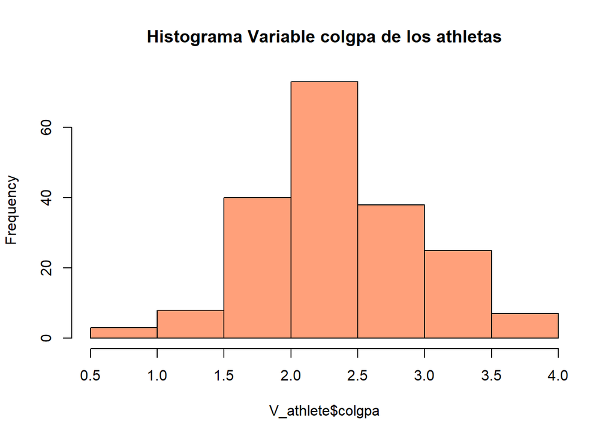

```r
V_athlete <- filter(gpa, gpa$athlete == TRUE)
V_no_athlete <- filter(gpa, gpa$athlete == FALSE)

h1 <- hist(V_athlete$colgpa ,col="lightsalmon",main="Histograma Variable colgpa de los athletas")
```

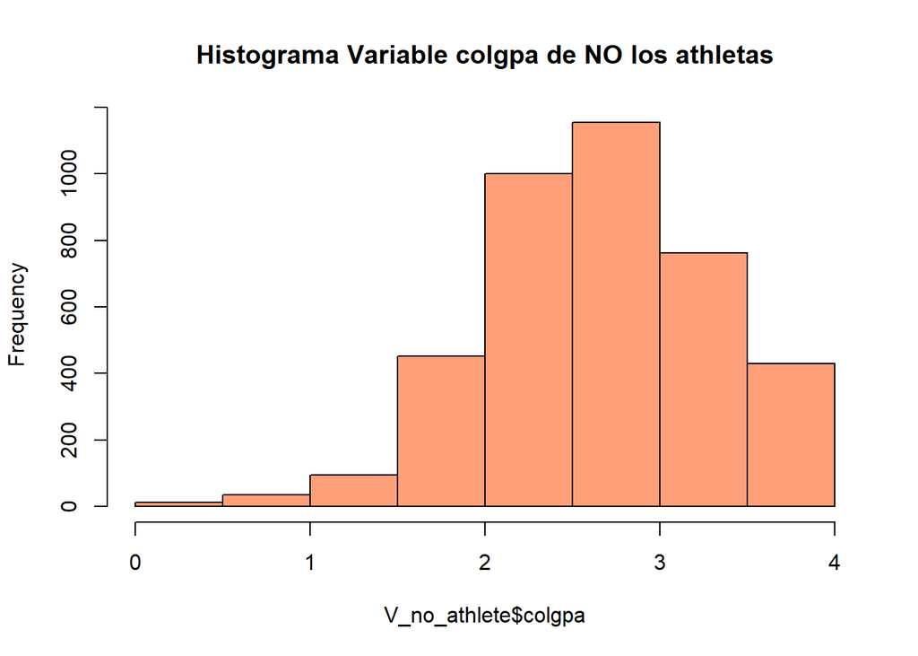

```r
h2 <- hist(V_no_athlete$colgpa ,col="lightsalmon",main="Histograma Variable colgpa de NO los athletas")
```

A nivel visual, nos damos cuenta de que las medias de los estudiantes no deportistas son mayores de los que sí lo son.

## 3.2 Función para el contraste de medias

```r
funcion_contraste_medias <- function( x1, x2, CL=0.95, Var_Igual=TRUE, metodo_calculo="two.sided" ){

  media_1<-mean(x1)
  length_1<-length(x1)
  sd1<-sd(x1)

  media_2<-mean(x2)
  length_2<-length(x2)
  sd2<-sd(x2)


  if (Var_Igual==TRUE){

      raiz <-sqrt( ((length_1-1)*sd1^2 + (length_2-1)*sd2^2 )/(length_1+length_2-2) )
      Sb <- raiz*sqrt(1/length_1 + 1/length_2)
      df<-(length_1 - 1) + (length_2 - 1)

  }else{

      Sb <- sqrt( sd1^2/length_1 + sd2^2/length_2 )
      denominador <- ( (sd1^2/length_1)^2/(length_1-1) + (sd2^2/length_2)^2/(length_2-1))
      df <- ( (sd1^2/length_1 + sd2^2/length_2)^2 ) / denominador

  }

  alfa <- (1-CL)
  t<- (media_1-media_2) / Sb


  if (metodo_calculo=="two.sided"){

      tcritical <- qt( alfa/2, df, lower.tail=FALSE )
      pvalue<-pt( abs(t), df, lower.tail=FALSE )*2

  }

  if (metodo_calculo=="greater"){

      tcritical <- qt( alfa, df, lower.tail=FALSE )
      pvalue<-pt( t, df, lower.tail=FALSE )

  }

  if (metodo_calculo=="less"){

      tcritical <- qt( alfa, df, lower.tail=TRUE )
      pvalue<-pt( t, df, lower.tail=TRUE )

  }


  resultados <-data.frame(t,tcritical,pvalue)

  return (resultados)

}
```

## 3.3 Pregunta de investigación

¿Ser atleta influye en la nota?

## 3.4 Hipótesis nula y la alternativa

H0 : µNotaAthleta = µNotaNoAthleta

H1 : µNotaAthleta < µNotaNoAthleta

## 3.5 Justificación del test a aplicar

La prueba para aplicar es la diferencia de medias, ya que tenemos dos grupos bien diferenciados, los deportistas y los no. Y al querer comprobar si la diferencia de notas influye a factor del deporte, esta prueba puede mostrar un resultado adecuado que pueda contestar la pregunta.

```r
#Comprobamos si las varianzas son iguales
var.test( gpa$colgpa[gpa$athlete == TRUE], gpa$colgpa[gpa$athlete == FALSE] )
```

```
##
##  F test to compare two variances
##
## data:  gpa$colgpa[gpa$athlete == TRUE] and gpa$colgpa[gpa$athlete == FALSE]
## F = 0.82199, num df = 193, denom df = 3942, p-value = 0.07287
## alternative hypothesis: true ratio of variances is not equal to 1
## 95 percent confidence interval:
##  0.6762059 1.0186147
## sample estimates:
## ratio of variances
##          0.8219902
```

## 3.6 Cálculo

```r
#Uso funcion implementada
funcion_contraste_medias( gpa$colgpa[gpa$athlete == TRUE], gpa$colgpa[gpa$athlete == FALSE], Var_Igual=TRUE, metodo_calculo = "two.sided")
```

```
##           t tcritical       pvalue
## 1 -5.910309  1.960538 3.689891e-09
```

```r
#Validación de la función
t.test( gpa$colgpa[gpa$athlete == TRUE], gpa$colgpa[gpa$athlete == FALSE], var.equal=TRUE, alternative = "two.sided")
```

```
##
##  Two Sample t-test
##
## data:  gpa$colgpa[gpa$athlete == TRUE] and gpa$colgpa[gpa$athlete == FALSE]
## t = -5.9103, df = 4135, p-value = 3.69e-09
## alternative hypothesis: true difference in means is not equal to 0
## 95 percent confidence interval:
##  -0.3792088 -0.1902956
## sample estimates:
## mean of x mean of y
##  2.382732  2.667484
```

## 3.7 Interpretación del test

El valor crítico para un nivel de confianza del 95% es 1.960538 y el valor observado es -5.910309. Con estos resultados en una zona de rechazo de la hipótesis nula y podemos concluir que los estudiantes no atletas tienen mejor nota que los que lo son.

Se concluye lo mismo con el valor P= 3.689891e-09, que es muy inferior al valor de alfa que es 0.05, comparando este resultado con los intervalos de confianza de los atletas y los que no lo son, llegamos a la misma conclusión en los dos casos.

# 4 ¿Las mujeres tienen mejor nota que los hombres?

## 4.1 Análisis visual

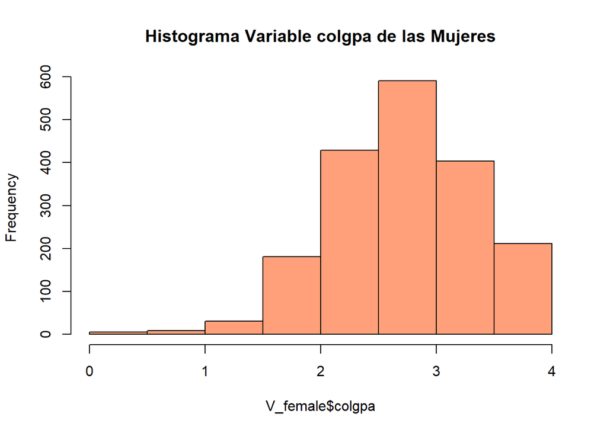

```r
V_female <- filter(gpa, gpa$female == TRUE)
V_no_female <- filter(gpa, gpa$female == FALSE)

h1 <- hist(V_female$colgpa ,col="lightsalmon",main="Histograma Variable colgpa de las Mujeres")
```

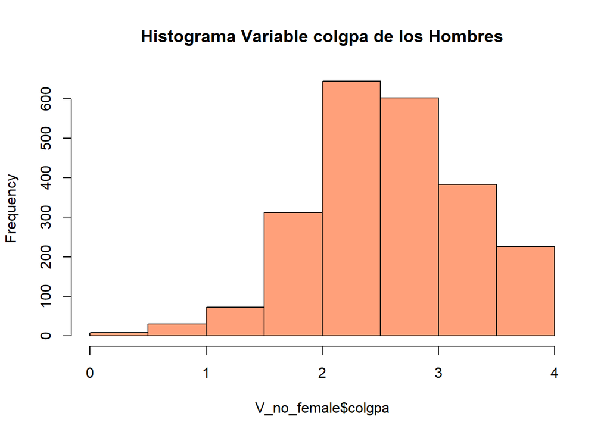

```r
h2 <- hist(V_no_female$colgpa ,col="lightsalmon",main="Histograma Variable colgpa de los Hombres")
```

## 4.2 Función para el contraste de medias

Usamos la misma función que para la pregunta anterior

## 4.3 Pregunta de investigación

¿Las mujeres tienen mejor nota que los hombres?

## 4.4 Hipótesis nula y la alternativa

H0 : µNotaMujer = µNotaHombre

H1 : µNotaMujer <= µNotaHombre

## 4.5 Justificación del test a aplicar al 95%

```r
#Comprobamos si las varianzas son iguales
var.test( gpa$colgpa[gpa$female == TRUE], gpa$colgpa[gpa$female == FALSE] )
```

```
##
##  F test to compare two variances
##
## data:  gpa$colgpa[gpa$female == TRUE] and gpa$colgpa[gpa$female == FALSE]
## F = 0.82757, num df = 1859, denom df = 2276, p-value = 2.024e-05
## alternative hypothesis: true ratio of variances is not equal to 1
## 95 percent confidence interval:
##  0.7590051 0.9026724
## sample estimates:
## ratio of variances
##          0.8275687
```

El resultado del test es un valor p < 0.001, por lo que se descarta la igualdad de varianzas de las poblaciones Mujeres y Hobres. Por lo que el tipo de test es con dos muestras distintas y varianzas diferentes.

## 4.6 Cálculo a 95%

```r
#Uso funcion implementada
funcion_contraste_medias( gpa$colgpa[gpa$female == TRUE], gpa$colgpa[gpa$female == FALSE], Var_Igual=FALSE, metodo_calculo = "two.sided")
```

```
##          t tcritical       pvalue
## 1 7.078735  1.960545 1.704394e-12
```

```r
#Validación de la función
t.test( gpa$colgpa[gpa$female == TRUE], gpa$colgpa[gpa$female == FALSE], var.equal=FALSE, alternative = "two.sided")
```

```
##
##  Welch Two Sample t-test
##
## data:  gpa$colgpa[gpa$female == TRUE] and gpa$colgpa[gpa$female == FALSE]
## t = 7.0787, df = 4087.4, p-value = 1.704e-12
## alternative hypothesis: true difference in means is not equal to 0
## 95 percent confidence interval:
##  0.1036283 0.1830188
## sample estimates:
## mean of x mean of y
##  2.733016  2.589693
```

## 4.8 Justificación del test a aplicar al 90%

```r
#Comprobamos si las varianzas son iguales
var.test( gpa$colgpa[gpa$female == TRUE], gpa$colgpa[gpa$female == FALSE], conf.level = 0.9 )
```

```
##
##  F test to compare two variances
##
## data:  gpa$colgpa[gpa$female == TRUE] and gpa$colgpa[gpa$female == FALSE]
## F = 0.82757, num df = 1859, denom df = 2276, p-value = 2.024e-05
## alternative hypothesis: true ratio of variances is not equal to 1
## 90 percent confidence interval:
##  0.7696299 0.8901446
## sample estimates:
## ratio of variances
##          0.8275687
```

El resultado del test es un valor p < 0.001, por lo que se descarta la igualdad de varianzas de las poblaciones Mujeres y Hobres. Por lo que el tipo de test es con dos muestras distintas y varianzas diferentes.

## 4.9 Cálculo a 90%

```r
#Uso funcion implementada
funcion_contraste_medias( gpa$colgpa[gpa$female == TRUE], gpa$colgpa[gpa$female == FALSE], CL=0.90, Var_Igual=FALSE, metodo_calculo = "two.sided")
```

```
##          t tcritical       pvalue
## 1 7.078735  1.645227 1.704394e-12
```

```r
#Validación de la función
t.test( gpa$colgpa[gpa$female == TRUE], gpa$colgpa[gpa$female == FALSE], var.equal=FALSE, conf.level = 0.9, alternative = "two.sided")
```

```
##
##  Welch Two Sample t-test
##
## data:  gpa$colgpa[gpa$female == TRUE] and gpa$colgpa[gpa$female == FALSE]
## t = 7.0787, df = 4087.4, p-value = 1.704e-12
## alternative hypothesis: true difference in means is not equal to 0
## 90 percent confidence interval:
##  0.1100126 0.1766345
## sample estimates:
## mean of x mean of y
##  2.733016  2.589693
```

## 4.10 Interpretación del test a 90%

# 5 ¿Hay diferencias en la nota según la raza?

## 5.1 Análisis visual

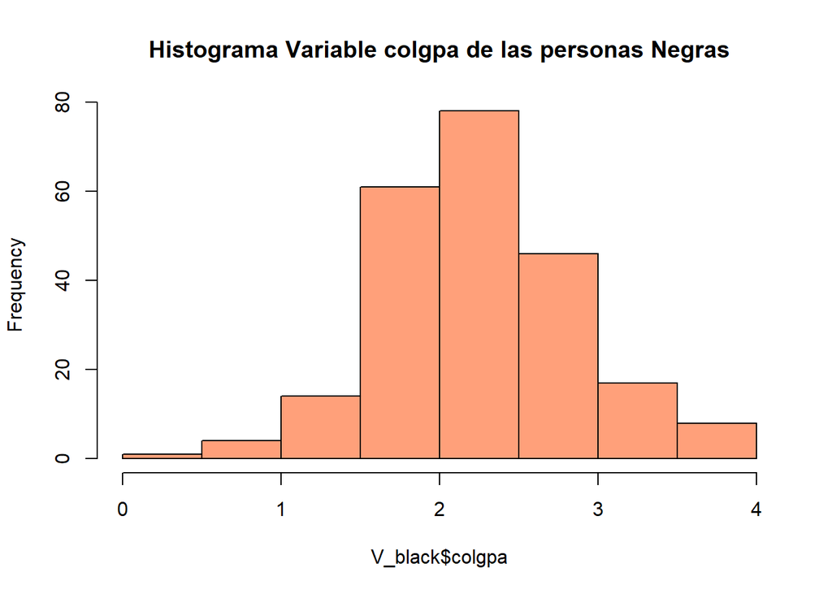

```r
V_black <- filter(gpa, gpa$black == TRUE)
V_white <- filter(gpa, gpa$white == TRUE)

h1 <- hist(V_black$colgpa ,col="lightsalmon",main="Histograma Variable colgpa de las personas Negras")
```

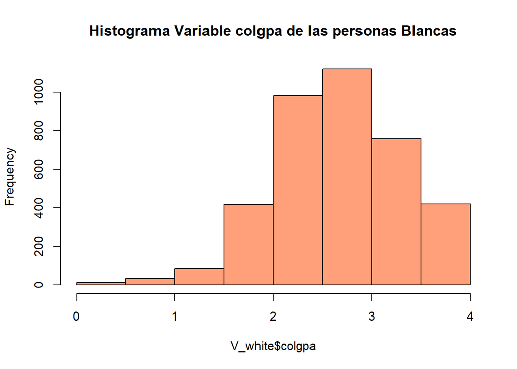

```r
h2 <- hist(V_white$colgpa ,col="lightsalmon",main="Histograma Variable colgpa de las personas Blancas")
```

A nivel visual, nos damos cuenta de que las medias de los estudiantes de raza blanca son mayores de los de raza negra.

## 5.2 Función para el contraste de medias

Usamos la misma función que para la pregunta anterior

## 5.3 Pregunta de investigación

¿Hay diferencias en la nota según la raza?

## 5.4 Hipótesis nula y la alternativa

H0 : µNotaRazaNegra = µNotaRazaBlanca

H1 : µNotaRazaNegra != µNotaRazaBlanca

## 5.5 Justificación del test a aplicar

```r
#Comprobamos si las varianzas son iguales
var.test( gpa$colgpa[gpa$white == TRUE], gpa$colgpa[gpa$black == TRUE] )
```

```
##
##  F test to compare two variances
##
## data:  gpa$colgpa[gpa$white == TRUE] and gpa$colgpa[gpa$black == TRUE]
## F = 1.127, num df = 3828, denom df = 228, p-value = 0.2343
## alternative hypothesis: true ratio of variances is not equal to 1
## 95 percent confidence interval:
##  0.9250878 1.3509805
## sample estimates:
## ratio of variances
##           1.126968
```

El resultado del test es un valor p > 0.001, por lo que NO se descarta la igualdad de varianzas de las poblaciones de Negros y Blancos. Por lo que el tipo de test es con dos muestras distintas y varianzas iguales.

## 5.6 Cálculo

```r
#Uso funcion implementada
funcion_contraste_medias( gpa$colgpa[gpa$white == TRUE], gpa$colgpa[gpa$black == TRUE], Var_Igual=TRUE, metodo_calculo = "two.sided")
```

```
##          t tcritical      pvalue
## 1 9.559319  1.960549 1.99014e-21
```

```r
#Validación de la función
t.test(gpa$colgpa[gpa$white == TRUE], gpa$colgpa[gpa$black == TRUE], var.equal=TRUE, alternative = "two.sided")
```

```
##
##  Two Sample t-test
##
## data:  gpa$colgpa[gpa$white == TRUE] and gpa$colgpa[gpa$black == TRUE]
## t = 9.5593, df = 4056, p-value < 2.2e-16
## alternative hypothesis: true difference in means is not equal to 0
## 95 percent confidence interval:
##  0.3360979 0.5095302
## sample estimates:
## mean of x mean of y
##  2.678360  2.255546
```

## 5.7 Interpretación del test

El valor crítico para un nivel de confianza del 95% es 1.960549 y el valor observado es 9.559319. Con estos resultados en una zona de rechazo de la hipótesis nula y podemos concluir que los estudiantes blancos tienen mejores notas que los estudiantes negros.

Se concluye lo mismo con el valor P=1.99014e-21, que es muy inferior al valor de alfa que es 0.05, comparando este resultado con los intervalos de confianza de las personas negras y blancas, llegamos a la misma conclusión en los dos casos.

# 6 Proporción de atletas

## 6.1 Análisis visual

[figure not shown]

```r
tabla <- table(gpa$athlete)

etiquetas <-paste0(round(100 * tabla/sum(tabla), 2), "%")

pie(tabla, labels = etiquetas, main="Proporción de personas Athletas entre los estudiantes")

legend("topleft", legend = c("TRUE", "FALSE"),
       fill =  c("White", "lightblue"))
```

A nivel visual, vemos que la proporción de deportista entre lo estudiantes es menor de los que lo son.

## 6.3 Hipótesis nula y la alternativa

H0 : p <= 0.5

H1 : p > 0.5

donde p es la proporción de athletas en la sociedad

## 6.4 Justificación del test a aplicar

Se debe realizar un test de una muestra sobre la proporción. Se calcula la proporción de estudiantes que son atletas es menor que la proporción de los que no lo son. Esta proporción se compara con el valor 0.5.

## 6.5 Realizad los cálculos del test

```r
n <- nrow(gpa)
p = (sum(gpa$athlete == TRUE))/ n;

p0 <- 0.5

Valor_Observado <- (p - p0)/ sqrt( p0*(1-p0)/n)
Valor_Critico <- qnorm( 0.05, lower.tail=FALSE )
pvalue <- pnorm( Valor_Observado, lower.tail=FALSE )

data.frame(p,Valor_Observado,Valor_Critico, pvalue)
```

```
##            p Valor_Observado Valor_Critico pvalue
## 1 0.04689388       -58.28713      1.644854      1
```

```r
#Comprobación del Test
prop.test( sum( gpa$athlete), n, p=0.5, correct=FALSE, alternative="greater")
```

```
##
##  1-sample proportions test without continuity correction
##
## data:  sum(gpa$athlete) out of n, null probability 0.5
## X-squared = 3397.4, df = 1, p-value = 1
## alternative hypothesis: true p is greater than 0.5
## 95 percent confidence interval:
##  0.04177721 1.00000000
## sample estimates:
##          p
## 0.04689388
```

# 7 ¿Hay más atletas entre los hombres que entre las mujeres?

## 7.1 Análisis visual

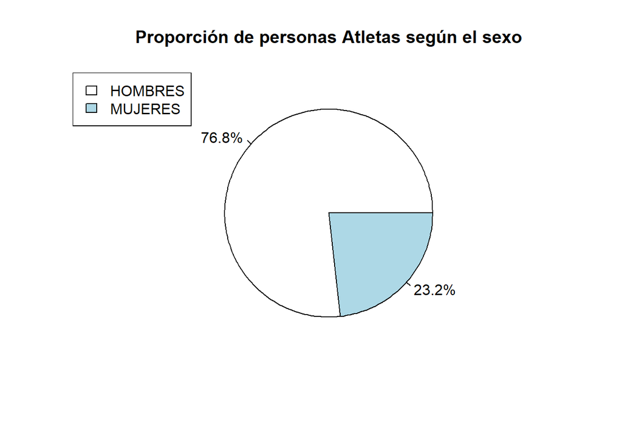

```r
tabla <- table(gpa$female[gpa$athlete==TRUE])

etiquetas <-paste0(round(100 * tabla/sum(tabla), 2), "%")

pie(tabla, labels = etiquetas, main="Proporción de personas Atletas según el sexo")
legend("topleft", legend = c("HOMBRES", "MUJERES"),
       fill =  c("White", "lightblue"))
```

A nivel visual, vemos que la proporción de deportistas entre las mujeres es menor que la de los hombres.

## 7.2 Pregunta de investigación

¿Hay más atletas entre los hombres que entre las mujeres?

## 7.3 Hipótesis nula y la alternativa

H0 : Phombres < Pmujeres

H1 : Phombres > Pmujeres

donde P es la proporción de athletas

## 7.5 Realizad los cálculos del test

```r
Pob.female <- gpa[gpa$female==TRUE,]
Pob.nfemale <- gpa[gpa$female==FALSE,]
n1 <-nrow(Pob.female)
n2<-nrow(Pob.nfemale)
p1 <- sum(Pob.female$athlete[Pob.female$athlete == TRUE]) / n1
p2 <- sum(Pob.nfemale$athlete[Pob.nfemale$athlete == TRUE]) / n2


p<- (n1*p1 + n2*p2) /(n1+n2)
z<- (p1-p2) / sqrt( p*(1-p)*(1/n1 + 1/n2))
zcrit <- qnorm(0.025)
pvalue <- pnorm(abs(z),lower.tail=FALSE)*2


data.frame(z, zcrit, pvalue)
```

```
##           z     zcrit       pvalue
## 1 -6.241964 -1.959964 4.321099e-10
```

```r
#Validación femaleando prop.test
success <- c(p1*n1,p2*n2)
n <- c(n1,n2)
prop.test( success, n, alternative="two.sided", correct=FALSE)
```

```
##
##  2-sample test for equality of proportions without continuity
##  correction
##
## data:  success out of n
## X-squared = 38.962, df = 1, p-value = 4.321e-10
## alternative hypothesis: two.sided
## 95 percent confidence interval:
##  -0.05356945 -0.02891741
## sample estimates:
##     prop 1     prop 2
## 0.02419355 0.06543698
```

# 8 Resumen y conclusiones

[output not shown]

# 9 Resumen ejecutivo